# Comprehensive Guide to Clustering Validation in R

Clustering Validation Tutorial

2025-12-03

# Introduction

Clustering validation is essential for evaluating the quality of clustering results. This tutorial demonstrates various clustering validation metrics in R using multiple packages and the famous `iris` dataset.

**Key concepts covered:**

- Internal validation measures (Silhouette, Dunn Index, Connectivity)
- Determining optimal number of clusters
- Stability measures
- Visual validation methods

# Load Required Packages

```r
# Install packages if needed
# install.packages(c("cluster", "factoextra", "clValid", "NbClust", "ggplot2"))

library(cluster)      # For silhouette, pam, and clustering functions
library(factoextra)   # For visualization functions
library(clValid)      # For comprehensive validation
library(NbClust)      # For multiple indices at once
library(ggplot2)      # For additional plotting
```

# Prepare Data

We’ll use the iris dataset, removing the species column for unsupervised clustering.

```r
# Load and prepare data
data("iris")
head(iris)
```

```
##   Sepal.Length Sepal.Width Petal.Length Petal.Width Species
## 1          5.1         3.5          1.4         0.2  setosa
## 2          4.9         3.0          1.4         0.2  setosa
## 3          4.7         3.2          1.3         0.2  setosa
## 4          4.6         3.1          1.5         0.2  setosa
## 5          5.0         3.6          1.4         0.2  setosa
## 6          5.4         3.9          1.7         0.4  setosa
```

```r
# Remove species column and scale the data
iris_data <- iris[, -5]
iris_scaled <- scale(iris_data)

# Check the scaled data
head(iris_scaled)
```

```
##      Sepal.Length Sepal.Width Petal.Length Petal.Width
## [1,]   -0.8976739  1.01560199    -1.335752   -1.311052
## [2,]   -1.1392005 -0.13153881    -1.335752   -1.311052
## [3,]   -1.3807271  0.32731751    -1.392399   -1.311052
## [4,]   -1.5014904  0.09788935    -1.279104   -1.311052
## [5,]   -1.0184372  1.24503015    -1.335752   -1.311052
## [6,]   -0.5353840  1.93331463    -1.165809   -1.048667
```

# Part 1: Determining Optimal Number of Clusters

## 1.1 Elbow Method (Within-Cluster Sum of Squares)

The elbow method plots the within-cluster sum of squares (WSS) against the number of clusters. The “elbow” point indicates a good number of clusters.

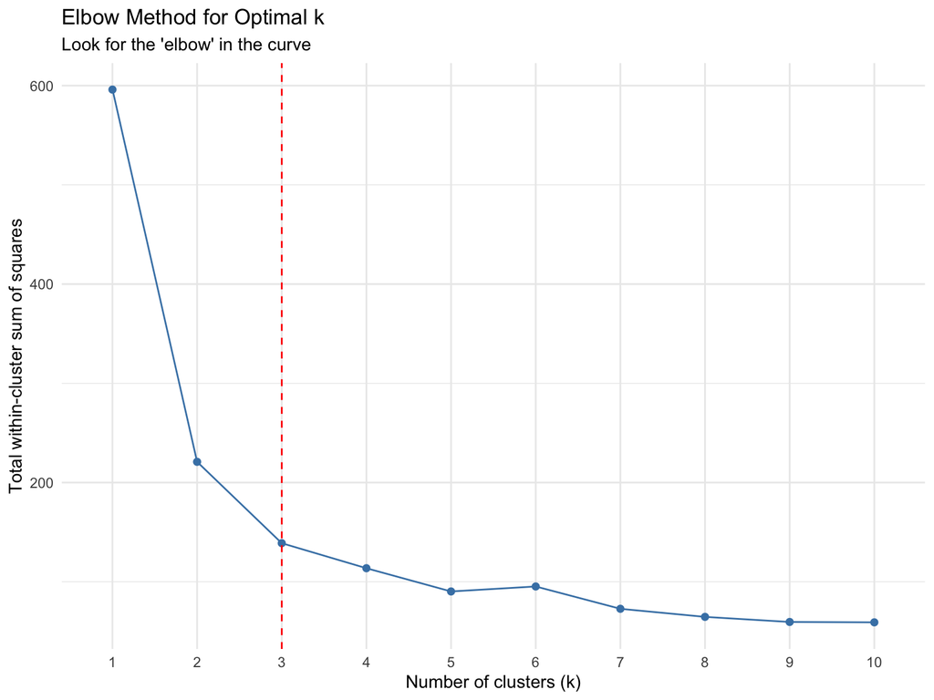

```r
# Elbow method using factoextra
fviz_nbclust(iris_scaled, kmeans, method = "wss") +
  geom_vline(xintercept = 3, linetype = 2, color = "red") +
  labs(title = "Elbow Method for Optimal k",
       subtitle = "Look for the 'elbow' in the curve",
       x = "Number of clusters (k)",
       y = "Total within-cluster sum of squares") +
  theme_minimal()
```

**Interpretation:** The plot shows the total WSS decreases as k increases. Look for the point where the decrease slows down dramatically (the “elbow”). For iris data, this appears around k=3.

## 1.2 Silhouette Method

The silhouette method measures how similar an object is to its own cluster compared to other clusters. Higher average silhouette width indicates better clustering.

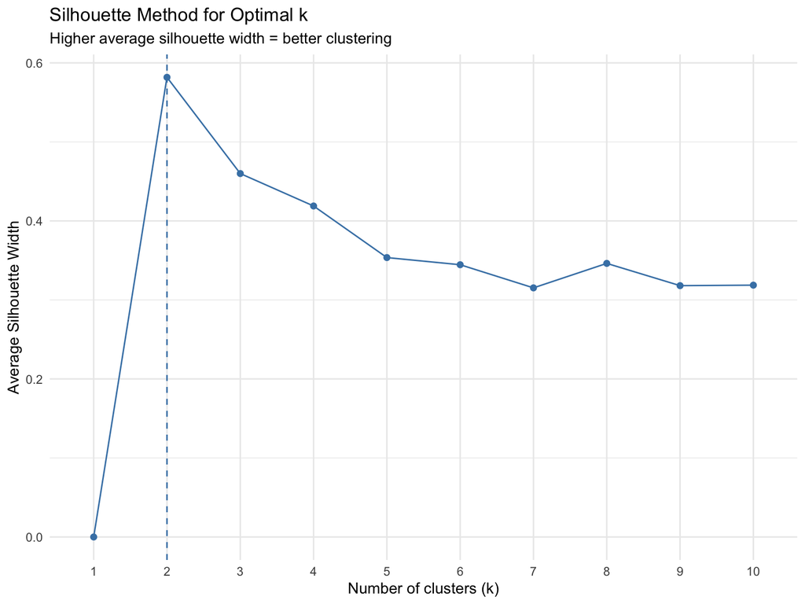

```r
# Silhouette method
fviz_nbclust(iris_scaled, kmeans, method = "silhouette") +
  labs(title = "Silhouette Method for Optimal k",
       subtitle = "Higher average silhouette width = better clustering",
       x = "Number of clusters (k)",
       y = "Average Silhouette Width") +
  theme_minimal()
```

**Interpretation:** The peak of the curve indicates the optimal number of clusters. Silhouette values range from -1 to 1:

- Close to 1: Well-clustered observations
- Close to 0: Borderline between two clusters
- Negative: Likely assigned to wrong cluster

## 1.3 Gap Statistic Method

The gap statistic compares the within-cluster variation to a null reference distribution of the data.

```r
# Compute gap statistic
set.seed(123)
gap_stat <- clusGap(iris_scaled, FUN = kmeans, nstart = 25,
                    K.max = 10, B = 50)

# Print results
print(gap_stat, method = "firstmax")
```

```
## Clustering Gap statistic ["clusGap"] from call:
## clusGap(x = iris_scaled, FUNcluster = kmeans, K.max = 10, B = 50, nstart = 25)
## B=50 simulated reference sets, k = 1..10; spaceH0="scaledPCA"
##  --> Number of clusters (method 'firstmax'): 3
##           logW   E.logW       gap     SE.sim
##  [1,] 4.534565 4.755428 0.2208634 0.02534324
##  [2,] 4.021316 4.490212 0.4688953 0.02670070
##  [3,] 3.806577 4.293793 0.4872159 0.02124741
##  [4,] 3.699263 4.140237 0.4409736 0.02177507
##  [5,] 3.589284 4.051459 0.4621749 0.01882154
##  [6,] 3.522810 3.975009 0.4521993 0.01753073
##  [7,] 3.448288 3.908834 0.4605460 0.01774025
##  [8,] 3.379870 3.852475 0.4726054 0.01727207
##  [9,] 3.310088 3.803931 0.4938436 0.01649671
## [10,] 3.278659 3.759003 0.4803440 0.01576050
```

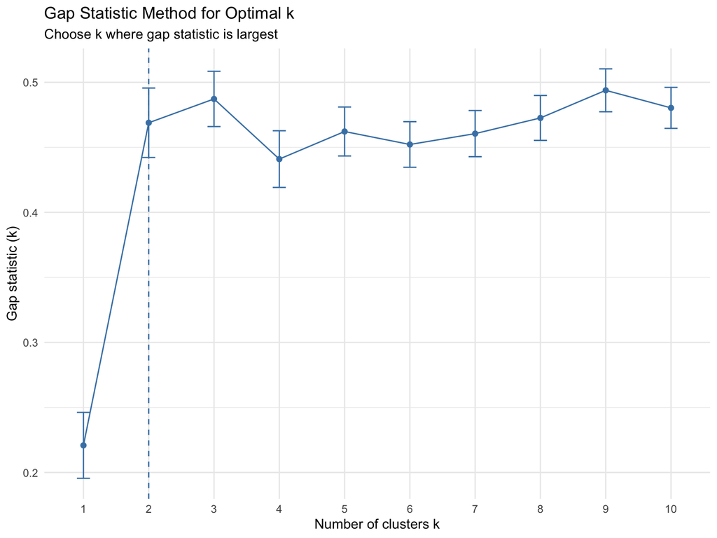

```r
# Visualize gap statistic
fviz_gap_stat(gap_stat) +
  labs(title = "Gap Statistic Method for Optimal k",
       subtitle = "Choose k where gap statistic is largest") +
  theme_minimal()
```

**Interpretation:** The optimal number of clusters is where the gap statistic is maximized. The method compares the observed within-cluster variation to that expected under a null reference distribution.

## 1.4 NbClust: Multiple Indices Simultaneously

NbClust provides 30 different indices for determining optimal cluster number in one function call.

```r
# Run NbClust with multiple indices
# Note: This may take some time as it computes 30 different indices
set.seed(123)
nb_result <- NbClust(data = iris_scaled,
                     distance = "euclidean",
                     min.nc = 2,
                     max.nc = 10,
                     method = "kmeans",
                     index = "all")
```

```r
# View the optimal number suggested by different indices
cat("Optimal number of clusters based on majority rule:\n")
```

```
## Optimal number of clusters based on majority rule:
```

```r
print(nb_result$Best.nc[1,])
```

```
##         KL         CH   Hartigan        CCC      Scott    Marriot     TrCovW
##          3          2          3          3          3          3          4
##     TraceW   Friedman      Rubin     Cindex         DB Silhouette       Duda
##          3          6          3          3          2          2          2
##   PseudoT2      Beale  Ratkowsky       Ball PtBiserial       Frey    McClain
##          2          2          2          3          2          3          2
##       Dunn     Hubert    SDindex     Dindex       SDbw
##          2          0          2          0         10
```

```r
# View how many indices proposed each k
table(nb_result$Best.nc[1,])
```

```
##
##  0  2  3  4  6 10
##  2 11 10  1  1  1
```

# Part 2: Detailed Silhouette Analysis

After determining optimal k, we perform detailed silhouette analysis.

```r
# Perform k-means clustering with k=3
set.seed(123)
km_result <- kmeans(iris_scaled, centers = 3, nstart = 25)

# Compute silhouette information
sil <- silhouette(km_result$cluster, dist(iris_scaled))

# Summary of silhouette
summary(sil)
```

```
## Silhouette of 150 units in 3 clusters from silhouette.default(x = km_result$cluster, dist = dist(iris_scaled)) :
##  Cluster sizes and average silhouette widths:
##        50        53        47
## 0.6363162 0.3933772 0.3473922
## Individual silhouette widths:
##     Min.  1st Qu.   Median     Mean  3rd Qu.     Max.
## -0.02489  0.35914  0.47113  0.45995  0.58883  0.73419
```

```
##   cluster size ave.sil.width
## 1       1   50          0.64
## 2       2   53          0.39
## 3       3   47          0.35
```

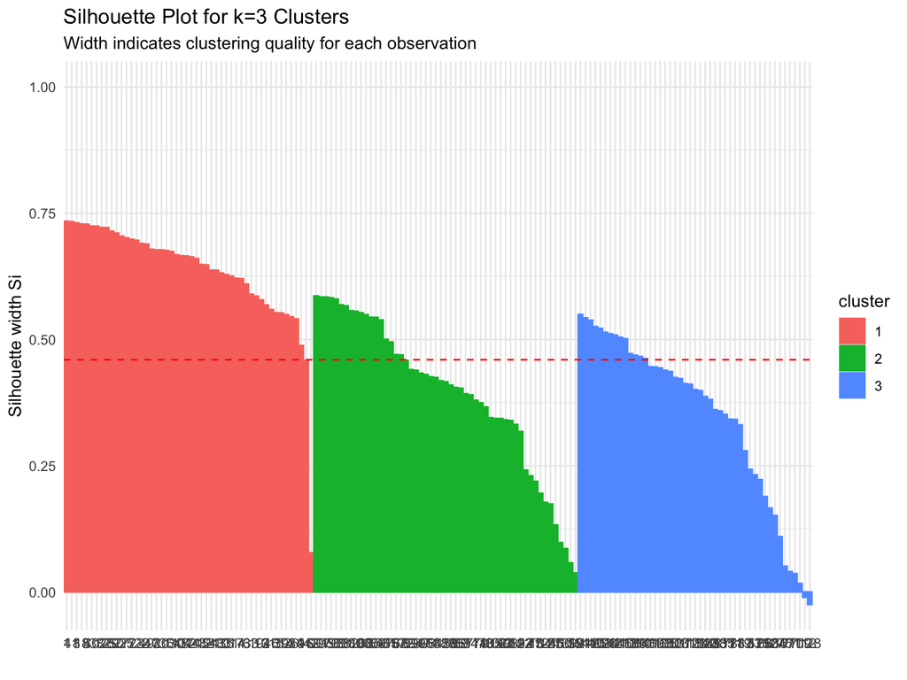

```r
# Plot silhouette
fviz_silhouette(sil) +
  labs(title = "Silhouette Plot for k=3 Clusters",
       subtitle = "Width indicates clustering quality for each observation") +
  theme_minimal()
```

## Identify Poorly Clustered Observations

```r
# Find observations with negative silhouette values
neg_sil_index <- which(sil[, "sil_width"] < 0)

if(length(neg_sil_index) > 0) {
  cat("Observations with negative silhouette (poorly clustered):\n")
  print(sil[neg_sil_index, , drop = FALSE])
  cat("\nThese", length(neg_sil_index),
      "observations may be assigned to the wrong cluster.\n")
} else {
  cat("No observations with negative silhouette values.\n")
}
```

```
## Observations with negative silhouette (poorly clustered):
##      cluster neighbor   sil_width
## [1,]       3        2 -0.01058434
## [2,]       3        2 -0.02489394
##
## These 2 observations may be assigned to the wrong cluster.
```

```r
# Find observations with low silhouette (< 0.25)
low_sil_index <- which(sil[, "sil_width"] < 0.25 & sil[, "sil_width"] >= 0)
if(length(low_sil_index) > 0) {
  cat("\nObservations with low silhouette (< 0.25):\n")
  print(head(sil[low_sil_index, , drop = FALSE]))
  cat("\nThese observations are borderline between clusters.\n")
}
```

```
##
## Observations with low silhouette (< 0.25):
##      cluster neighbor  sil_width
## [1,]       1        2 0.07766666
## [2,]       3        2 0.16627565
## [3,]       2        3 0.13270610
## [4,]       3        2 0.23206569
## [5,]       2        3 0.03768897
## [6,]       3        2 0.18906699
##
## These observations are borderline between clusters.
```

## Compare Different Numbers of Clusters

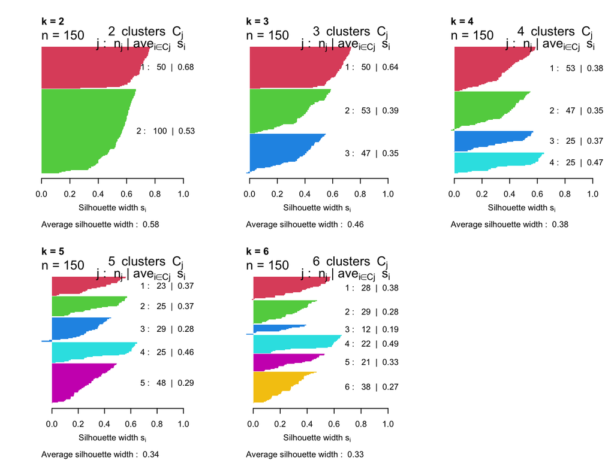

```r
# Compare silhouettes for k = 2 to 6
par(mfrow = c(2, 3))
for(k in 2:6) {
  set.seed(123)
  km_temp <- kmeans(iris_scaled, centers = k, nstart = 25)
  sil_temp <- silhouette(km_temp$cluster, dist(iris_scaled))
  plot(sil_temp, main = paste("k =", k),
       col = 2:(k+1), border = NA)
}
par(mfrow = c(1, 1))
```

# Part 3: Comprehensive Validation with clValid

The clValid package provides internal, stability, and biological validation measures.

## 3.1 Internal Validation

Internal measures include Connectivity, Dunn Index, and Silhouette Width.

```r
# Perform internal validation
# Compare multiple clustering methods and numbers of clusters
clmethods <- c("hierarchical", "kmeans", "pam")

intern <- clValid(iris_scaled,
                  nClust = 2:6,
                  clMethods = clmethods,
                  validation = "internal")

# Summary of results
summary(intern)
```

```
##
## Clustering Methods:
##  hierarchical kmeans pam
##
## Cluster sizes:
##  2 3 4 5 6
##
## Validation Measures:
##                                  2       3       4       5       6
##
## hierarchical Connectivity   0.9762  5.5964  7.5492 18.0508 24.7306
##              Dunn           0.2674  0.1874  0.2060  0.0700  0.0762
##              Silhouette     0.5818  0.4803  0.4067  0.3746  0.3248
## kmeans       Connectivity   0.9762 23.8151 25.9183 40.3198 40.1524
##              Dunn           0.2674  0.0265  0.0700  0.0808  0.0808
##              Silhouette     0.5818  0.4599  0.4189  0.3455  0.3441
## pam          Connectivity   0.9762 23.0726 31.8067 35.7964 44.5413
##              Dunn           0.2674  0.0571  0.0566  0.0642  0.0361
##              Silhouette     0.5818  0.4566  0.4091  0.3574  0.3400
##
## Optimal Scores:
##
##              Score  Method       Clusters
## Connectivity 0.9762 hierarchical 2
## Dunn         0.2674 hierarchical 2
## Silhouette   0.5818 hierarchical 2
```

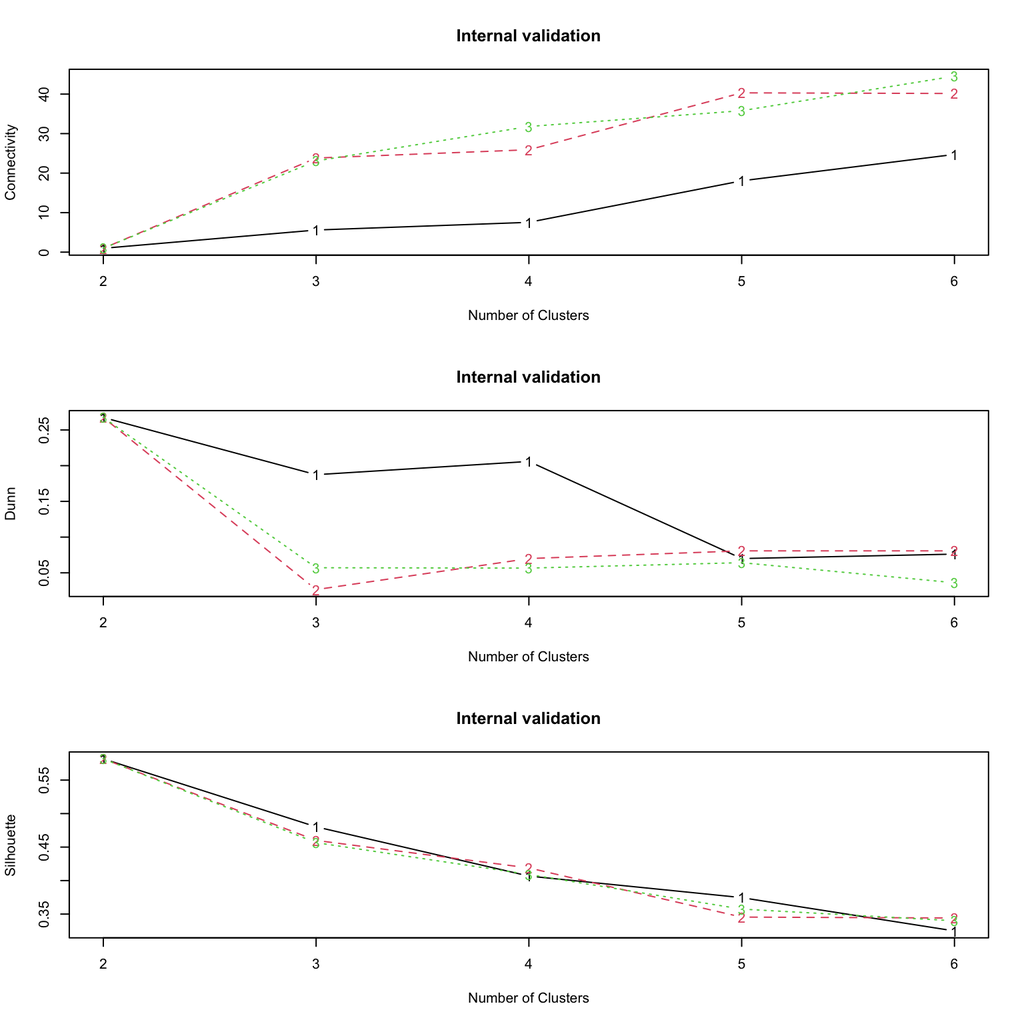

```r
# Visualize internal measures
par(mfrow = c(3, 1))
plot(intern, legend = FALSE)
```

```r
par(mfrow = c(1, 1))

# Get optimal scores
optimalScores(intern)
```

```
##                  Score       Method Clusters
## Connectivity 0.9761905 hierarchical        2
## Dunn         0.2674261 hierarchical        2
## Silhouette   0.5817500 hierarchical        2
```

**Interpretation of Internal Measures:**

- **Connectivity**: Measures how well observations are placed with their nearest neighbors. **Minimize** this value (range: 0 to ∞).
- **Dunn Index**: Ratio of smallest inter-cluster distance to largest intra-cluster distance. **Maximize** this value (range: 0 to ∞).
- **Silhouette Width**: Average silhouette value across all observations. **Maximize** this value (range: -1 to 1).

## 3.2 Stability Validation

Stability measures evaluate how consistent clustering is when data is perturbed (removing one sample at a time).

```r
# Perform stability validation
# This takes longer as it requires resampling
stab <- clValid(iris_scaled,
                nClust = 2:6,
                clMethods = clmethods,
                validation = "stability")

# Summary
summary(stab)
```

```
##
## Clustering Methods:
##  hierarchical kmeans pam
##
## Cluster sizes:
##  2 3 4 5 6
##
## Validation Measures:
##                        2      3      4      5      6
##
## hierarchical APN  0.0033 0.0370 0.0859 0.1088 0.1342
##              AD   1.4924 1.4601 1.4015 1.3269 1.2251
##              ADM  0.0161 0.1451 0.1448 0.3919 0.3176
##              FOM  0.5957 0.5809 0.5571 0.5334 0.5101
## kmeans       APN  0.0128 0.1034 0.1290 0.2130 0.2950
##              AD   1.5060 1.2685 1.1568 1.1269 1.0949
##              ADM  0.0555 0.2152 0.2147 0.4499 0.5147
##              FOM  0.6049 0.5206 0.4888 0.4805 0.4910
## pam          APN  0.0128 0.1162 0.1420 0.1655 0.1886
##              AD   1.5060 1.2721 1.1665 1.0726 1.0043
##              ADM  0.0555 0.2266 0.2500 0.2834 0.2814
##              FOM  0.6049 0.5032 0.4828 0.4789 0.4558
##
## Optimal Scores:
##
##     Score  Method       Clusters
## APN 0.0033 hierarchical 2
## AD  1.0043 pam          6
## ADM 0.0161 hierarchical 2
## FOM 0.4558 pam          6
```

```r
# Optimal scores
optimalScores(stab)
```

```
##           Score       Method Clusters
## APN 0.003266667 hierarchical        2
## AD  1.004288856          pam        6
## ADM 0.016087089 hierarchical        2
## FOM 0.455750052          pam        6
```

**Interpretation of Stability Measures:**

- **APN (Average Proportion of Non-overlap)**: Average proportion of observations not placed in same cluster. **Minimize** (range: 0 to 1).
- **AD (Average Distance)**: Average distance between observations in same cluster. **Minimize**.
- **ADM (Average Distance between Means)**: Average distance between cluster centers. **Minimize**.
- **FOM (Figure of Merit)**: Average intra-cluster variance. **Minimize**.

# Part 4: Dunn Index Calculation

The Dunn Index is the ratio of the minimum inter-cluster distance to the maximum intra-cluster distance.

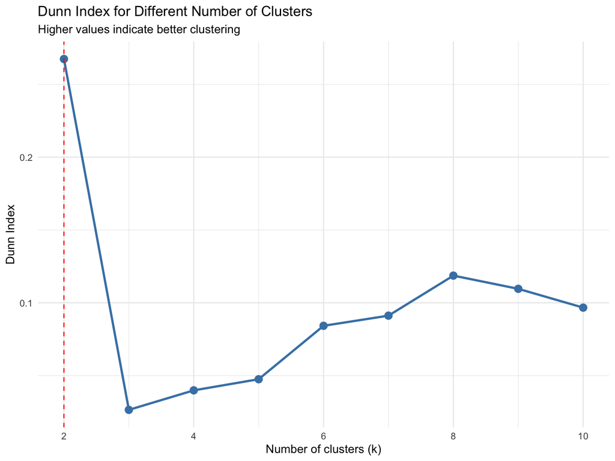

```r
# Calculate Dunn Index for different k values
dunn_values <- sapply(2:10, function(k) {
  set.seed(123)
  km <- kmeans(iris_scaled, centers = k, nstart = 25)
  dunn(distance = dist(iris_scaled), clusters = km$cluster)
})

# Plot Dunn Index
dunn_df <- data.frame(k = 2:10, dunn = dunn_values)

ggplot(dunn_df, aes(x = k, y = dunn)) +
  geom_line(color = "steelblue", size = 1) +
  geom_point(color = "steelblue", size = 3) +
  geom_vline(xintercept = which.max(dunn_values) + 1,
             linetype = "dashed", color = "red") +
  labs(title = "Dunn Index for Different Number of Clusters",
       subtitle = "Higher values indicate better clustering",
       x = "Number of clusters (k)",
       y = "Dunn Index") +
  theme_minimal()
```

```r
cat("Optimal k based on Dunn Index:", which.max(dunn_values) + 1, "\n")
```

```
## Optimal k based on Dunn Index: 2
```

```r
cat("Maximum Dunn Index value:", max(dunn_values), "\n")
```

```
## Maximum Dunn Index value: 0.2674261
```

# Part 5: PAM Clustering with Validation

Partitioning Around Medoids (PAM) is more robust to outliers than k-means.

```r
# Perform PAM clustering
set.seed(123)
pam_result <- pam(iris_scaled, k = 3)

# Summary
summary(pam_result)
```

```
## Medoids:
##       ID Sepal.Length Sepal.Width Petal.Length Petal.Width
## [1,]   8   -1.0184372   0.7861738   -1.2791040  -1.3110521
## [2,] 113    1.1553023  -0.1315388    0.9868021   1.1816087
## [3,]  56   -0.1730941  -0.5903951    0.4203256   0.1320673
## Clustering vector:
##   [1] 1 1 1 1 1 1 1 1 1 1 1 1 1 1 1 1 1 1 1 1 1 1 1 1 1 1 1 1 1 1 1 1 1 1 1 1 1
##  [38] 1 1 1 1 1 1 1 1 1 1 1 1 1 2 2 2 3 3 3 2 3 3 3 3 3 3 3 3 2 3 3 3 3 3 3 3 3
##  [75] 3 2 2 2 3 3 3 3 3 3 3 3 2 3 3 3 3 3 3 3 3 3 3 3 3 3 2 3 2 2 2 2 3 2 2 2 2
## [112] 2 2 3 2 2 2 2 2 3 2 3 2 3 2 2 3 3 2 2 2 2 2 3 3 2 2 2 3 2 2 2 3 2 2 2 3 2
## [149] 2 3
## Objective function:
##     build      swap
## 0.9205107 0.8757051
##
```

[output cut: 170 more lines]

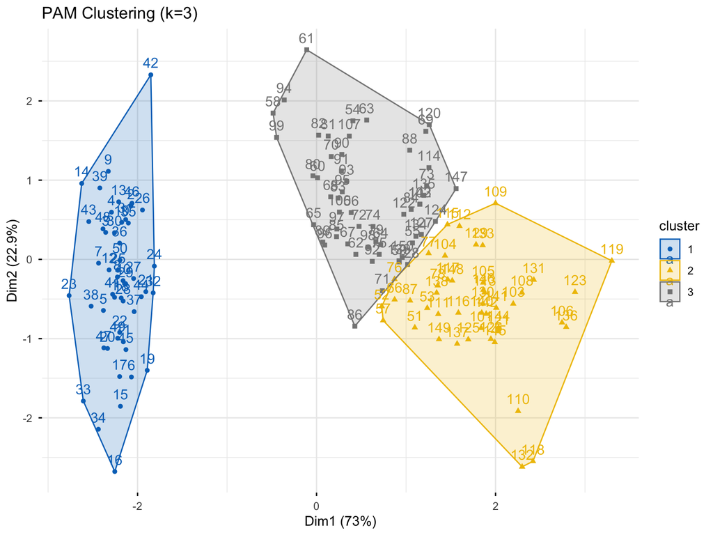

```r
# Visualize PAM clustering
fviz_cluster(pam_result,
             data = iris_scaled,
             ellipse.type = "convex",
             palette = "jco",
             ggtheme = theme_minimal(),
             main = "PAM Clustering (k=3)")
```

```
##   cluster size ave.sil.width
## 1       1   50          0.63
## 2       2   45          0.35
## 3       3   55          0.38
```

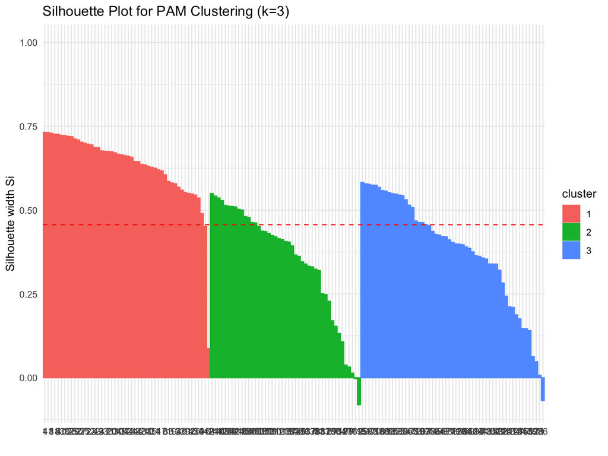

```r
# Silhouette plot for PAM
fviz_silhouette(pam_result) +
  labs(title = "Silhouette Plot for PAM Clustering (k=3)") +
  theme_minimal()
```

# Part 6: Hierarchical Clustering with Validation

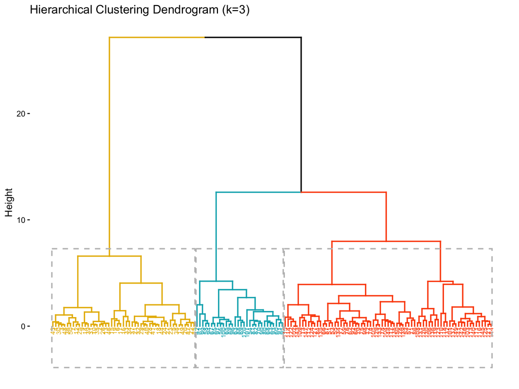

```r
# Perform hierarchical clustering
set.seed(123)
hc_result <- hcut(iris_scaled, k = 3, hc_method = "ward.D2")

# Visualize dendrogram
fviz_dend(hc_result,
          rect = TRUE,
          cex = 0.5,
          main = "Hierarchical Clustering Dendrogram (k=3)",
          k_colors = c("#E7B800", "#00AFBB", "#FC4E07"))
```

```
##   cluster size ave.sil.width
## 1       1   49          0.63
## 2       2   30          0.44
## 3       3   71          0.32
```

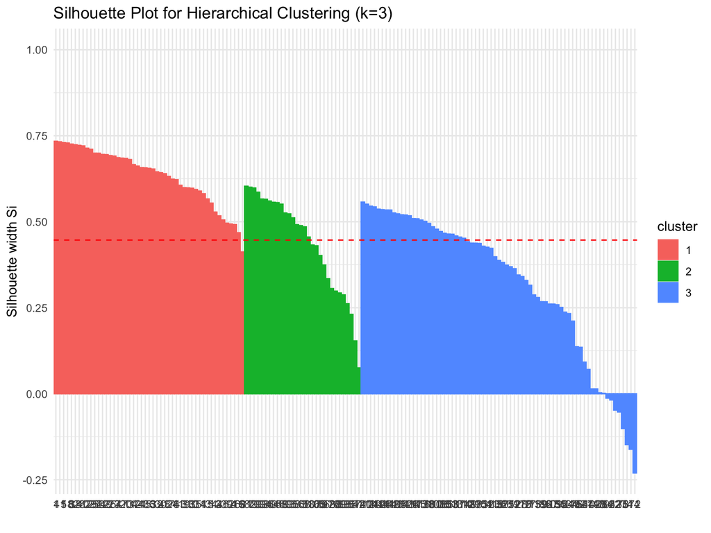

```r
# Silhouette for hierarchical clustering
fviz_silhouette(hc_result) +
  labs(title = "Silhouette Plot for Hierarchical Clustering (k=3)") +
  theme_minimal()
```

# Part 7: Cluster Visualization and Comparison

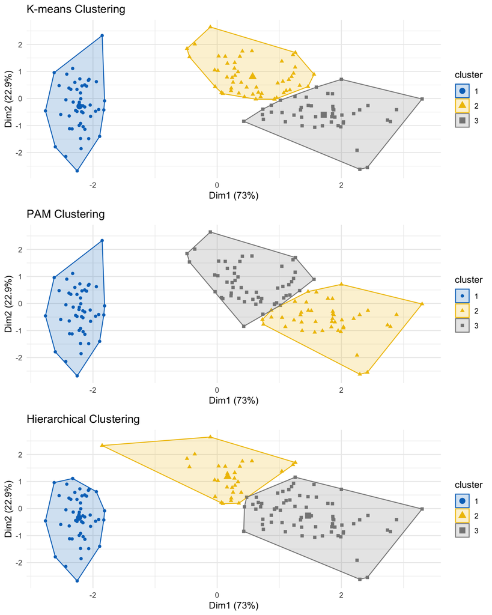

```r
# Compare three clustering methods side by side
set.seed(123)

# K-means
km3 <- kmeans(iris_scaled, centers = 3, nstart = 25)
p1 <- fviz_cluster(list(data = iris_scaled, cluster = km3$cluster),
                   geom = "point",
                   ellipse.type = "convex",
                   palette = "jco",
                   main = "K-means Clustering") +
  theme_minimal()

# PAM
pam3 <- pam(iris_scaled, k = 3)
p2 <- fviz_cluster(pam3,
                   geom = "point",
                   ellipse.type = "convex",
                   palette = "jco",
                   main = "PAM Clustering") +
  theme_minimal()

# Hierarchical
hc3 <- hcut(iris_scaled, k = 3, hc_method = "ward.D2")
p3 <- fviz_cluster(list(data = iris_scaled, cluster = hc3$cluster),
                   geom = "point",
                   ellipse.type = "convex",
                   palette = "jco",
                   main = "Hierarchical Clustering") +
  theme_minimal()

# Arrange plots
gridExtra::grid.arrange(p1, p2, p3, ncol = 1)
```